# Midterm Decision

### Decision

The purpose of this analysis is to decide whether or not to keep my midterm score. My decision is based on past data of students’ midterm and final exam scores.

After following the process outlined in the `Technical Process` tab, I believe this to be the true model:

$$Y_i = \underbrace{\beta_0 + \beta_1 X_i}_\text{The True Model} + \epsilon_i$$
I can estimate that model by the following equation:

$$\hat{Y}_i = -8.454 + 1.011 X_i$$

The following is a plot of `FinalExam` as explained by `Midterm`. My midterm score, predicted final exam score and the simple linear regression line are included.

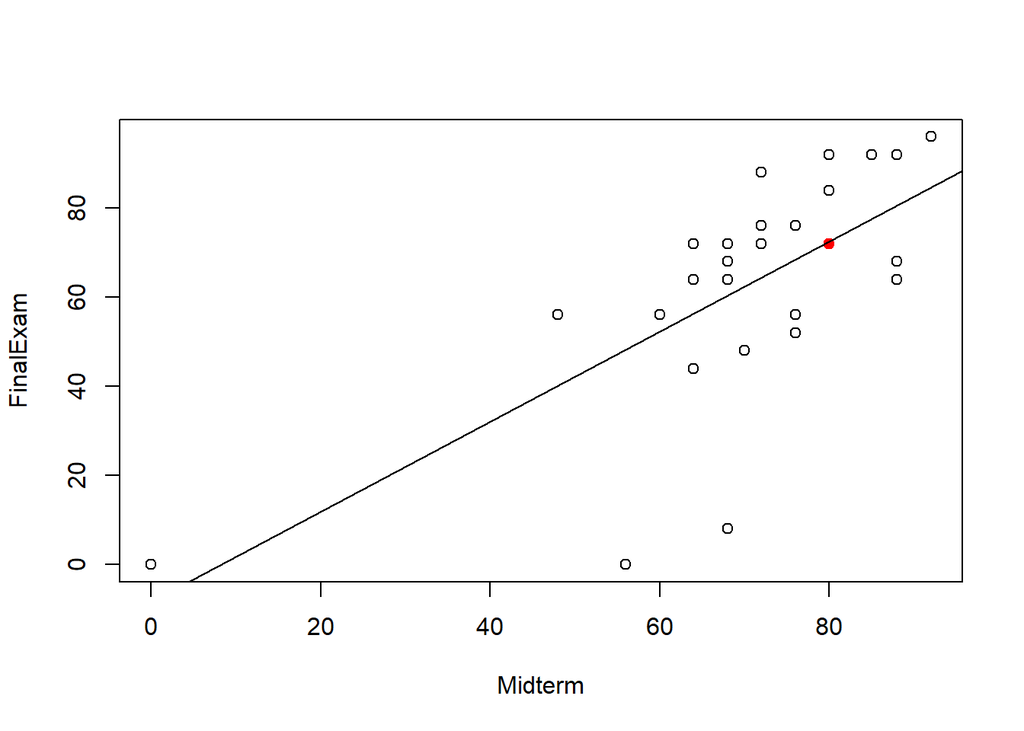

```r
plot(FinalExam ~ Midterm, data = grades)
points(x = 80, y = 72, pch = 19, col = "red")
abline(lm(FinalExam ~ Midterm, data = grades))
```

Based on what I have been able to uncover from the data, I am choosing to keep my midterm score.

### Technical Process

I started with looking at the data on a plot and overlaying it with a very simple linear regression line in red and a lowess curve in blue.

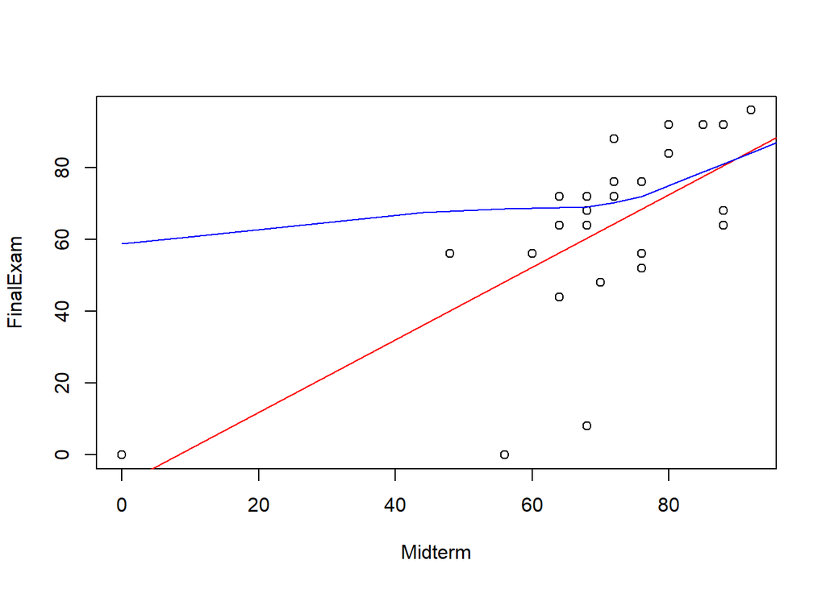

```r
midterm.lm <- lm(FinalExam ~ Midterm, data = grades) #Just a good 'ol lm

plot(FinalExam ~ Midterm, data = grades)
abline(lm(FinalExam ~ Midterm, data = grades), col = "red") #Plotting the initial lm
lines(lowess(grades$FinalExam, grades$Midterm), col = "blue") #Plotting the lowess curve
```

```r
pander(summary(midterm.lm)) #Summary of our inital lm
```

|  | Estimate | Std. Error | t value | Pr(>\|t\|) |
| --- | --- | --- | --- | --- |
| **(Intercept)** | -8.454 | 12.97 | -0.6517 | 0.5201 |
| **Midterm** | 1.011 | 0.1863 | 5.431 | 9.595e-06 |

Fitting linear model: FinalExam ~ Midterm

| Observations | Residual Std. Error | $R^2$ | Adjusted $R^2$ |
| --- | --- | --- | --- |
| 29 | 20.91 | 0.5221 | 0.5044 |

Looking at the plot it appears that our linear model doesn’t quite totally fit the data. There may be a need for a two line model or something. The Lowess curve also suggests that a linear model isn’t sufficient to explain what’s happening with the data.

Note, the P-value is significant (9.595e-06) and the Adjusted R^2 indicates that only about half of the `FinalExam` scores are explained by the `MidTerm` scores (0.5044).

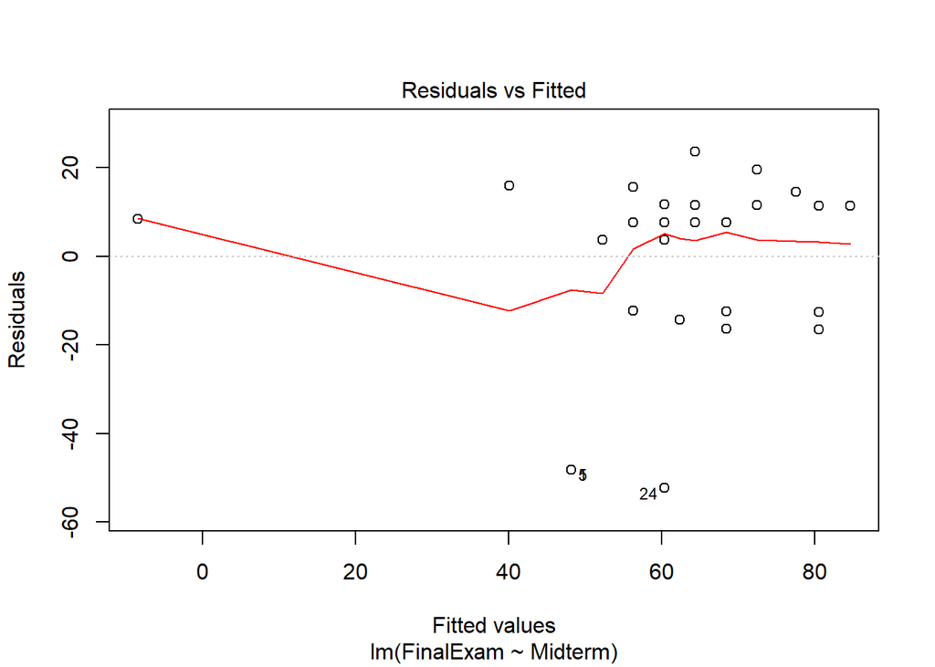

```r
plot(midterm.lm, which = 1) #Produces residuals vs fitted plot
```

The Residuals vs Fitted plot shows a bit of concern for variance of the error terms. We also want to note that points 5 and 24 are outliers that we may need to remove.

To begin digging into the data, I created a pairs plot. Looking at that, our hope is to find somewhere that shows which variables are good indicators of `FinalExam` scores.

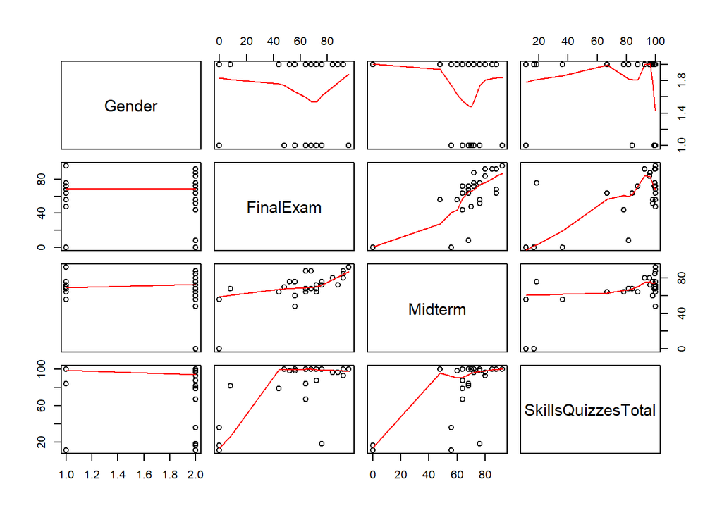

```r
pairs(grades, panel = panel.smooth) #Produces a pairs plot between all the variables in the dataset
```

It appears that the `Midterm` score and `SkillsQuizzesTotal` may both be useful. It doesn’t seem like `Gender` has much significance so we’re going to disregard that variable for now.

I wanted to begin with the most “useful” variable for predicting the `FinalExam` score (which appears to be the `Midterm` score). We went over that at the beginning of the analysis. Next, I want to build a new pairs plot that includes the Residual and Fitted values of the `midterm.lm`.

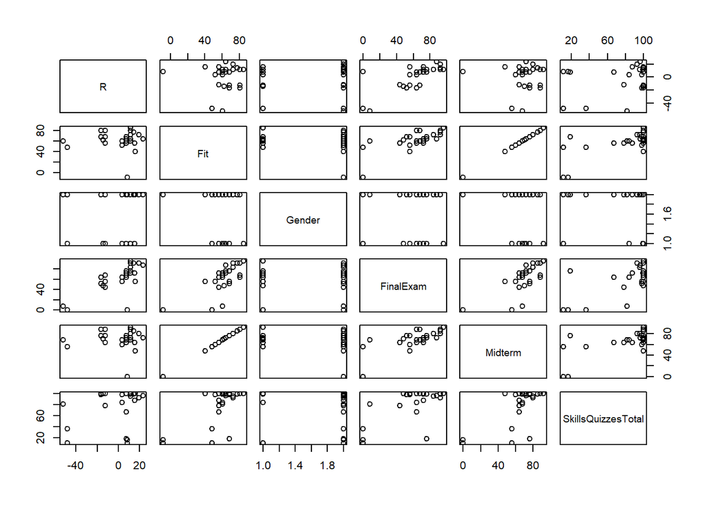

```r
pairs(cbind(R = midterm.lm$res, Fit = midterm.lm$fit, grades))
```

It looks like `SkillsQuizzesTotal` may have some linearity. Considering that, I created a second linear model, this time including `SkillsQuizzesTotal` as a second variable.

```r
multiple.lm <- lm(FinalExam ~ Midterm + SkillsQuizzesTotal, data = grades)

pander(summary(multiple.lm))
```

|  | Estimate | Std. Error | t value | Pr(>\|t\|) |
| --- | --- | --- | --- | --- |
| **(Intercept)** | -15.43 | 12.2 | -1.265 | 0.2171 |
| **Midterm** | 0.6278 | 0.2296 | 2.734 | 0.01111 |
| **SkillsQuizzesTotal** | 0.3969 | 0.1591 | 2.494 | 0.01932 |

Fitting linear model: FinalExam ~ Midterm + SkillsQuizzesTotal

| Observations | Residual Std. Error | $R^2$ | Adjusted $R^2$ |
| --- | --- | --- | --- |
| 29 | 19.14 | 0.6143 | 0.5847 |

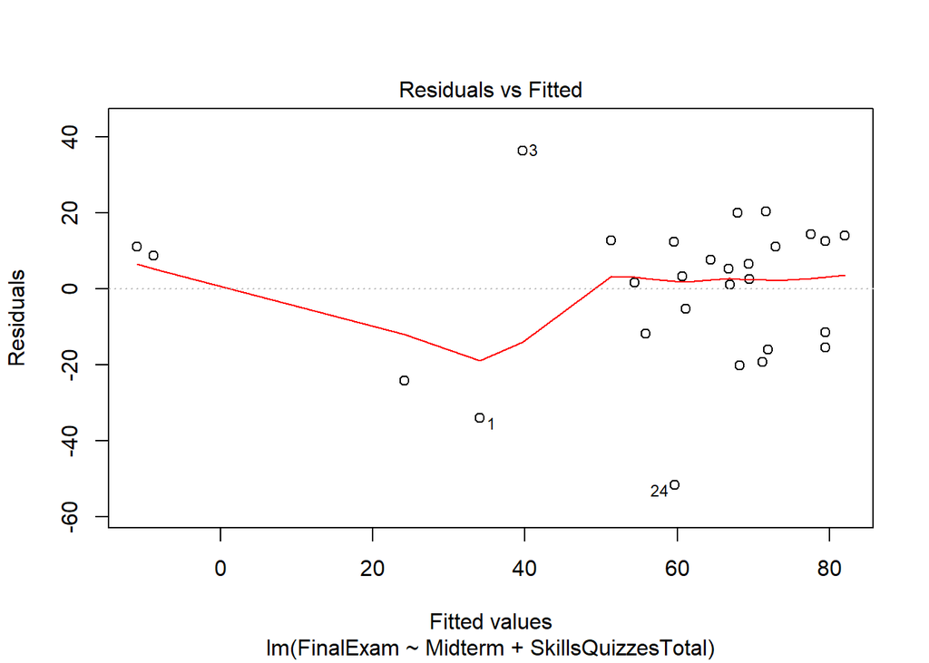

```r
par(mfrow=c(1,1))
plot(multiple.lm, which = 1:1)
```

Out of curiosity I wanted to see what it’d look like to only use `SkillsQuizzesTotal` as the explanatory variable.

```r
quizzes.lm <- lm(FinalExam ~ SkillsQuizzesTotal, data = grades)

pander(summary(quizzes.lm))
```

|  | Estimate | Std. Error | t value | Pr(>\|t\|) |
| --- | --- | --- | --- | --- |
| **(Intercept)** | 2.44 | 11.47 | 0.2128 | 0.8331 |
| **SkillsQuizzesTotal** | 0.6883 | 0.1316 | 5.232 | 1.633e-05 |

Fitting linear model: FinalExam ~ SkillsQuizzesTotal

| Observations | Residual Std. Error | $R^2$ | Adjusted $R^2$ |
| --- | --- | --- | --- |
| 29 | 21.32 | 0.5035 | 0.4851 |

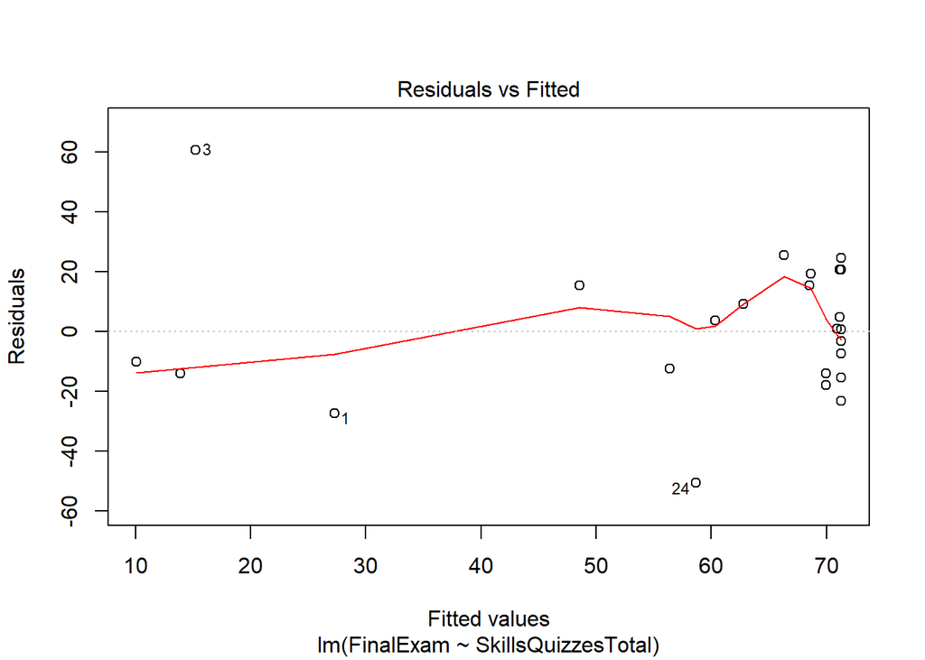

```r
par(mfrow=c(1,1))
plot(quizzes.lm, which = 1:1)
```

The adjusted R^2 isn’t any better (0.4851) so I think we’ll go back to considering `Midterm` as the main explanatory variable.

Since that didn’t pan out, I figured we should probably check for an interaction between `Midterm` and `SkillsQuizzesTotal`.

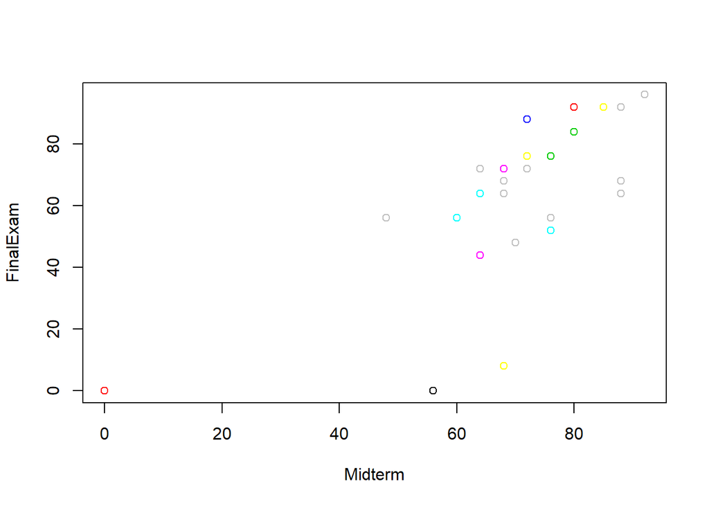

```r
plot(FinalExam ~ Midterm, data = grades, col=as.factor(SkillsQuizzesTotal))
```

```r
interaction.lm <- lm(FinalExam ~ Midterm + SkillsQuizzesTotal + Midterm:SkillsQuizzesTotal, data=grades)

pander(summary(interaction.lm))
```

|  | Estimate | Std. Error | t value | Pr(>\|t\|) |
| --- | --- | --- | --- | --- |
| **(Intercept)** | -9.258 | 16.4 | -0.5645 | 0.5774 |
| **Midterm** | 0.4975 | 0.3255 | 1.529 | 0.1389 |
| **SkillsQuizzesTotal** | 0.2054 | 0.3711 | 0.5536 | 0.5848 |
| **Midterm:SkillsQuizzesTotal** | 0.003099 | 0.00541 | 0.5728 | 0.5719 |

Fitting linear model: FinalExam ~ Midterm + SkillsQuizzesTotal + Midterm:SkillsQuizzesTotal

| Observations | Residual Std. Error | $R^2$ | Adjusted $R^2$ |
| --- | --- | --- | --- |
| 29 | 19.4 | 0.6193 | 0.5736 |

This wasn’t super insightful either. Looking at the data now, I realize that factoring by `SkillsQuizzesTotal` doesn’t make a ton of sense because it’s a variable with many levels. Although the R^2 increased a bit, our p-values are now all insignificant.

Honestly, I’m not sure where to go after this. I decided to finally make my decision based solely on `Midterm`.

```r
pander(predict(midterm.lm, newdata = data.frame(Midterm = 80), interval = "prediction"))
```

| fit | lwr | upr |
| --- | --- | --- |
| 72.47 | 28.52 | 116.4 |

Based on the prediction range, my final exam score could be anywhere from a 28 to 116. Of course that’s not a super helpful range. It’d be nice if I could get a 116 but that’s not really possible. The fitted prediction is 72%.